# SIM_CM1_C_M0725055

Viza Kiswara

2026-05-26

# Analisis dan Visualisasi Database Sakila

Kategori Film, Tren Rental, dan Analisis Statistik Inferensial

**Viza Kiswara** | M0725055 | Kelas C

Program Studi Statistika  
Universitas Sebelas Maret  
Sistem Informasi Manajemen

26 May 2026

# 1 Pendahuluan

Database **Sakila** merupakan *sample database* MySQL yang merepresentasikan sistem rental DVD.  
Laporan ini bertujuan menganalisis kategori film dan tren rental menggunakan visualisasi data serta analisis statistik inferensial.

Fokus analisis meliputi:  
1. **Kategori Film**  
2. **Tren Rental**  
3. **Analisis Statistik Inferensial**

# 2 Koneksi Database MySQL

## 2.1 Load Library

```r
# Library utama
library(DBI)          # Koneksi & query database
library(odbc)         # Driver ODBC untuk MySQL
library(dplyr)        # Manipulasi data
library(tidyr)        # Tidy data
library(ggplot2)      # Visualisasi data
library(scales)       # Format sumbu (dollar, comma)
library(knitr)        # Render tabel
library(kableExtra)   # Styling tabel
library(lubridate)    # Manipulasi tanggal & waktu
library(forcats)      # Manipulasi faktor
library(gridExtra)    # Gabungkan beberapa plot
```

## 2.2 Membuat Koneksi ke MySQL

Pastikan database Sakila dan MySQL ODBC Connector sudah terpasang sebelum menjalankan kode berikut.

```r
# Koneksi MySQL
consak <- dbConnect(odbc(),
          Driver   = "MySQL ODBC 8.0 ANSI Driver",
          Server   = "127.0.0.1",
          Database = "sakila",
          UID      = "root",
          PWD      = "WJ28@krhps",
          Port     = 3306
)

# Menampilkan daftar tabel
tabel_sakila <- dbGetQuery(consak, "SHOW FULL TABLES")
tabel_sakila
```

| Tables_in_sakila | Table_type |
| --- | --- |
| actor | BASE TABLE |
| actor_info | VIEW |
| address | BASE TABLE |
| category | BASE TABLE |
| city | BASE TABLE |
| country | BASE TABLE |
| customer | BASE TABLE |
| customer_list | VIEW |
| film | BASE TABLE |
| film_actor | BASE TABLE |

[output cut: 13 more lines]

## 2.3 Ringkasan Database

```r
ringkasan <- data.frame(
  Keterangan = c(
    "Total Film",
    "Total Pelanggan",
    "Total Transaksi",
    "Total Revenue"
  ),
  Nilai = c(
    dbGetQuery(consak, "SELECT COUNT(*) AS n FROM film")$n,
    dbGetQuery(consak, "SELECT COUNT(*) AS n FROM customer")$n,
    dbGetQuery(consak, "SELECT COUNT(*) AS n FROM payment")$n,
    round(dbGetQuery(consak, "SELECT SUM(amount) AS total FROM payment")$total, 2)
  )
)
kable(
  ringkasan,
  caption = "Ringkasan Database Sakila"
)
```

Ringkasan Database Sakila

| Keterangan | Nilai |
| --- | --- |
| Total Film | 1000 |
| Total Pelanggan | 599 |
| Total Transaksi | 16044 |
| Total Revenue | 67406 |

# 3 Insight 1: Kategori Film

## 3.1 Deskripsi Insight

Analisis ini dilakukan untuk melihat:  
1. Kategori film yang paling sering dirental  
2. Kategori dengan revenue tertinggi  
3. Hubungan antara jumlah rental dan revenue

## 3.2 Query SQL dan Analisis Data (Poin 1)

```r
query_kategori <- "
SELECT
  c.name AS category,
  COUNT(DISTINCT r.rental_id) AS total_rental,
  SUM(p.amount) AS total_revenue,
  AVG(f.length) AS avg_length,
  AVG(f.rental_rate) AS avg_rate
FROM category c
JOIN film_category fc ON c.category_id = fc.category_id
JOIN film f ON fc.film_id = f.film_id
JOIN inventory i ON f.film_id = i.film_id
JOIN rental r ON i.inventory_id = r.inventory_id
JOIN payment p ON r.rental_id = p.rental_id
GROUP BY c.name
ORDER BY total_revenue DESC
"
cat_summary <- dbGetQuery(consak, query_kategori)
kable(
  cat_summary,
  caption = "Ringkasan Kategori Film"
)
```

Ringkasan Kategori Film

| category | total_rental | total_revenue | avg_length | avg_rate |
| --- | --- | --- | --- | --- |
| Sports | 1179 | 5314.21 | 128.7498 | 3.068032 |
| Sci-Fi | 1101 | 4756.98 | 105.5649 | 2.988183 |
| Animation | 1166 | 4656.30 | 108.7787 | 2.760154 |
| Drama | 1060 | 4587.39 | 122.6047 | 3.182453 |
| Comedy | 941 | 4383.58 | 111.7109 | 3.283305 |
| Action | 1112 | 4375.85 | 108.7455 | 2.668058 |
| New | 940 | 4351.62 | 109.0500 | 3.090000 |
| Games | 969 | 4281.33 | 128.1538 | 3.130351 |
| Foreign | 1033 | 4270.67 | 123.1249 | 2.953214 |
| Family | 1096 | 4226.07 | 111.3294 | 2.699854 |
| Documentary | 1050 | 4217.52 | 110.9714 | 2.616667 |
| Horror | 846 | 3722.54 | 113.3227 | 3.101111 |
| Children | 945 | 3655.55 | 111.4423 | 2.689471 |
| Classics | 939 | 3639.59 | 113.0618 | 2.638562 |
| Travel | 837 | 3549.64 | 117.0072 | 3.317360 |
| Music | 830 | 3417.72 | 115.7036 | 3.062289 |

Query di atas digunakan untuk menghitung jumlah rental, total revenue, rata-rata durasi film, dan rata-rata harga sewa pada setiap kategori film.

## 3.3 Visualisasi Data (Poin 2)

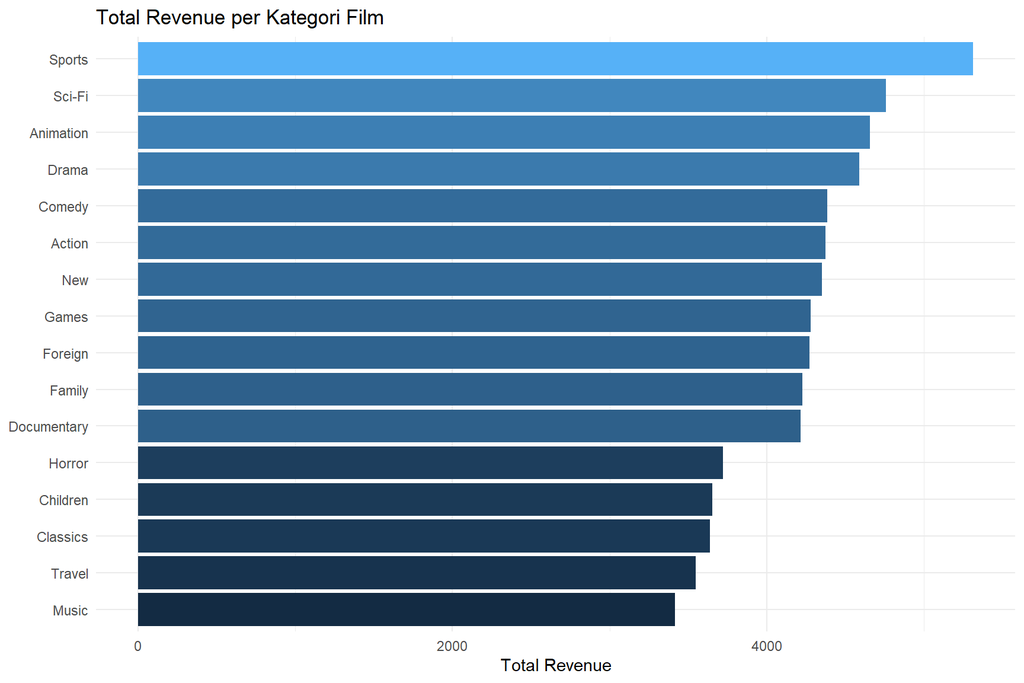

```r
cat_summary |>
  mutate(category = fct_reorder(category, total_revenue)) |>
  ggplot(aes(
    x = total_revenue,
    y = category,
    fill = total_revenue
  )) +
  geom_col(show.legend = FALSE) +
  labs(
    title = "Total Revenue per Kategori Film",
    x = "Total Revenue",
    y = NULL
  ) +
  theme_minimal()
```

Visualisasi digunakan untuk membandingkan total revenue pada setiap kategori film sehingga kategori dengan pendapatan tertinggi dapat terlihat dengan lebih jelas.

## 3.4 Visualisasi Data (Poin 3)

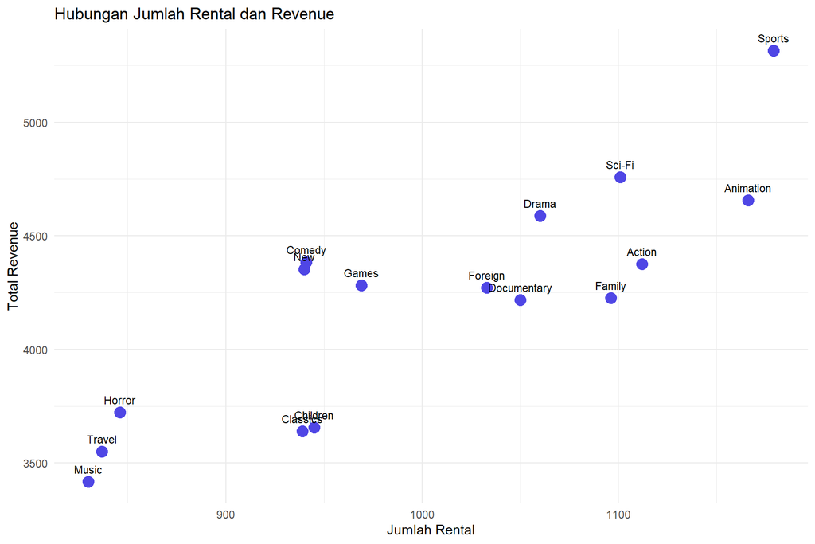

```r
ggplot(
  cat_summary,
  aes(
    x = total_rental,
    y = total_revenue
  )
) +
  geom_point(size = 4, color = "#4f46e5") +
  geom_text(
    aes(label = category),
    vjust = -1,
    size = 3
  ) +
  labs(
    title = "Hubungan Jumlah Rental dan Revenue",
    x = "Jumlah Rental",
    y = "Total Revenue"
  ) +
  theme_minimal()
```

Visualisasi digunakan untuk melihat hubungan antara jumlah rental dan total revenue pada setiap kategori film.

## 3.5 Interpretasi

Berdasarkan hasil analisis, kategori Sports menjadi kategori dengan performa terbaik karena memiliki jumlah rental dan total revenue tertinggi. Hal ini menunjukkan bahwa film kategori Sports paling sering dirental sekaligus paling besar kontribusinya terhadap pendapatan.

Kategori Sci-Fi, Animation, dan Drama juga termasuk kategori yang cukup diminati karena memiliki revenue dan jumlah rental yang tinggi. Sebaliknya, kategori seperti Music, Travel, dan Horror memiliki performa lebih rendah dibanding kategori lainnya.

Dari visualisasi scatter plot terlihat bahwa terdapat hubungan positif antara jumlah rental dan total revenue. Semakin banyak suatu kategori dirental, maka revenue yang dihasilkan juga cenderung meningkat.

Selain itu, kategori dengan revenue tinggi tidak selalu memiliki rata-rata durasi film paling panjang. Hal ini menunjukkan bahwa pendapatan lebih dipengaruhi oleh tingkat popularitas dan frekuensi rental dibanding durasi film.

# 4 Insight 2: Tren Rental

## 4.1 Deskripsi Insight

Analisis ini dilakukan untuk melihat:  
1. Bagaimana pola rental berubah dari bulan ke bulan?  
2. Hari apa yang paling ramai?  
3. Berapa rata-rata durasi pelanggan menyewa film?

## 4.2 Rumus Rata-rata Durasi Rental

$$\bar{D} = \frac{1}{n} \sum_{i=1}^{n} (D_i)$$
dengan:
$$D_i = \text{return date}_i - \text{rental date}_i$$
Dimana $D_i$ dihitung dalam satuan hari.

## 4.3 Query SQL dan Analisis Data (Poin 1)

```r
query_bulanan <- "
  SELECT
    DATE_FORMAT(p.payment_date, '%Y-%m-01') AS bulan,
    COUNT(DISTINCT r.rental_id)             AS total_rental,
    SUM(p.amount)                           AS total_revenue
  FROM payment p
  JOIN rental r ON p.rental_id = r.rental_id
  GROUP BY DATE_FORMAT(p.payment_date, '%Y-%m-01')
  ORDER BY bulan
"
tren_bulanan <- dbGetQuery(consak, query_bulanan)
tren_bulanan$bulan <- as.Date(tren_bulanan$bulan)
kable(
  tren_bulanan,
  caption = "Ringkasan Tren Rental Bulanan"
)
```

Ringkasan Tren Rental Bulanan

| bulan | total_rental | total_revenue |
| --- | --- | --- |
| 2005-05-01 | 1156 | 4823.44 |
| 2005-06-01 | 2311 | 9629.89 |
| 2005-07-01 | 6709 | 28368.91 |
| 2005-08-01 | 5686 | 24070.14 |
| 2006-02-01 | 182 | 514.18 |

Query di atas digunakan untuk melihat jumlah rental dan total revenue setiap bulan.

## 4.4 Visualisasi Data (Poin 1)

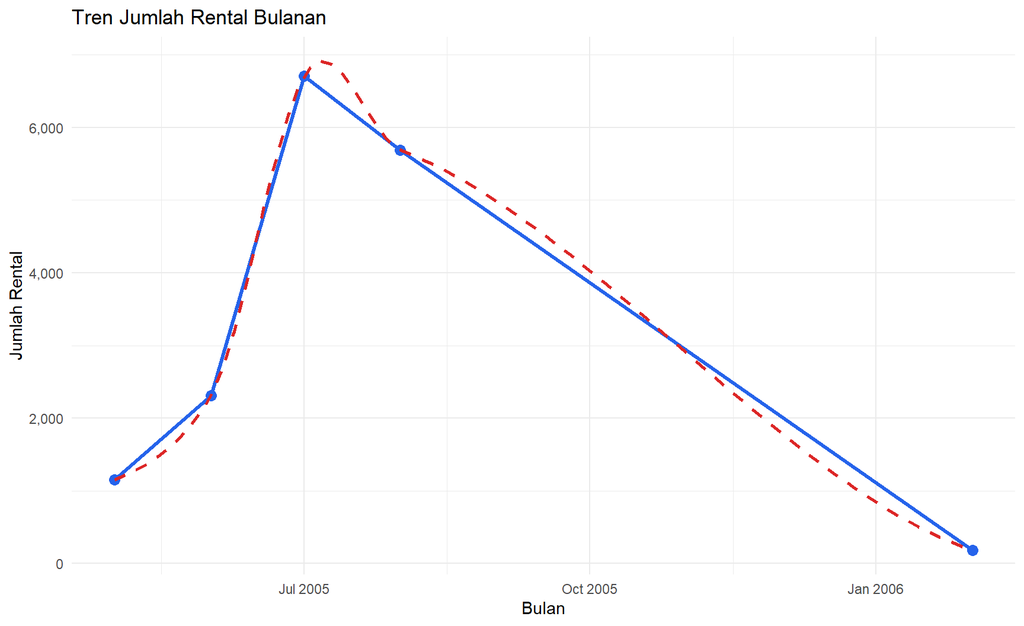

```r
ggplot(tren_bulanan, aes(x = bulan, y = total_rental, group = 1)) +
  geom_line(color = "#2563eb", linewidth = 1.2) +
  geom_point(color = "#2563eb", size = 3) +
  geom_smooth(method = "loess", se = FALSE, linetype = "dashed",
              color = "#dc2626") +
  scale_x_date(date_labels = "%b %Y") +
  scale_y_continuous(labels = comma) +
  labs(
    title = "Tren Jumlah Rental Bulanan",
    x = "Bulan",
    y = "Jumlah Rental"
  ) +
  theme_minimal()
```

Visualisasi ini menunjukkan perubahan jumlah rental dari bulan ke bulan serta kecenderungan trennya.

## 4.5 Query SQL dan Analisis Data (Poin 2)

```r
query_heatmap <- "
  SELECT
    MONTH(rental_date)   AS bulan,
    DAYNAME(rental_date) AS hari,
    COUNT(rental_id)     AS total_rental
  FROM rental
  GROUP BY MONTH(rental_date), DAYNAME(rental_date)
  ORDER BY bulan
"
heatmap_data <- dbGetQuery(consak, query_heatmap)
heatmap_data$hari <- factor(
  heatmap_data$hari,
  levels = c("Monday","Tuesday","Wednesday","Thursday",
             "Friday","Saturday","Sunday")
)
kable(
  head(heatmap_data),
  caption = "Contoh Data Pola Rental per Hari dan Bulan"
)
```

Contoh Data Pola Rental per Hari dan Bulan

| bulan | hari | total_rental |
| --- | --- | --- |
| 2 | Tuesday | 182 |
| 5 | Friday | 166 |
| 5 | Monday | 158 |
| 5 | Saturday | 196 |
| 5 | Sunday | 154 |
| 5 | Thursday | 174 |

Query ini digunakan untuk melihat pola rental per hari dan bulan.

## 4.6 Visualisasi Data (Poin 2)

[figure not shown]

```r
ggplot(heatmap_data,
       aes(x = factor(bulan), y = hari, fill = total_rental)) +
  geom_tile(color = "white") +
  geom_text(aes(label = total_rental), size = 3, color = "white") +
  scale_fill_gradient(low = "#bfdbfe", high = "#1d4ed8") +
  scale_x_discrete(labels = c("Jan","Feb","Mar","Apr","Mei","Jun",
                             "Jul","Agu","Sep","Okt","Nov","Des")) +
  labs(
    title = "Pola Rental Berdasarkan Hari dan Bulan",
    x = "Bulan",
    y = NULL
  ) +
  theme_minimal()
```

Visualisasi ini memperlihatkan hari-hari dengan aktivitas rental tertinggi.

## 4.7 Query SQL dan Analisis Data (poin 3)

```r
query_durasi <- "
  SELECT
    TIMESTAMPDIFF(DAY, rental_date, return_date) AS durasi_hari
  FROM rental
  WHERE return_date IS NOT NULL
"
durasi_data <- dbGetQuery(consak, query_durasi)
avg_dur <- mean(durasi_data$durasi_hari)
med_dur <- median(durasi_data$durasi_hari)
kable(
  data.frame(
    mean = avg_dur,
    median = med_dur
  ),
  caption = "Rata-rata dan Median Durasi Rental"
)
```

Rata-rata dan Median Durasi Rental

| mean | median |
| --- | --- |
| 4 | 5 |

Query ini digunakan untuk menghitung rata-rata (mean) dan median durasi rental.

## 4.8 Visualisasi Data (Poin 3)

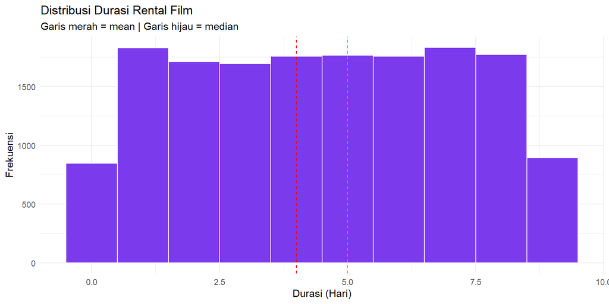

```r
ggplot(durasi_data, aes(x = durasi_hari)) +
  geom_histogram(binwidth = 1, fill = "#7c3aed", color = "white") +
  geom_vline(xintercept = avg_dur, linetype = "dashed", color = "red") +
  geom_vline(xintercept = med_dur, linetype = "dashed", color = "green") +
  labs(
    title = "Distribusi Durasi Rental Film",
    subtitle = "Garis merah = mean | Garis hijau = median",
    x = "Durasi (Hari)",
    y = "Frekuensi"
  ) +
  theme_minimal()
```

Visualisasi ini menunjukkan sebaran durasi rental film serta perbandingan antara rata-rata dan median.

# 5 Insight 3: Analisis Statistik Inferensial

## 5.1 Deskripsi Insight

Analisis ini dilakukan untuk melihat:  
1. Apakah rata-rata spending pelanggan aktif berbeda signifikan dengan pelanggan tidak aktif?

## 5.2 Hipotesis (Poin 1)

$$H_0: \mu_{\text{aktif}} =
\mu_{\text{tidak aktif}}$$
$$H_1:
\mu_{\text{aktif}} \neq \mu_{\text{tidak aktif}}$$

$$t = \frac{\bar{X}_{\text{aktif}} -
\bar{X}_{\text{tidak
aktif}}}{\sqrt{\dfrac{s_{\text{aktif}}^2}{n_{\text{aktif}}} +
\dfrac{s_{\text{tidak aktif}}^2}{n_{\text{tidak aktif}}}}}$$
Tolak $H_0$ jika $p\text{-value} < \alpha = 0{,}05$

## 5.3 Query SQL dan Persiapan Data

```r
query_cust <- "
  SELECT
    c.customer_id,
    c.active,
    COUNT(DISTINCT r.rental_id) AS total_rental,
    SUM(p.amount)               AS total_spending,
    AVG(p.amount)               AS avg_spending
  FROM customer c
  JOIN rental r  ON c.customer_id = r.customer_id
  JOIN payment p ON r.rental_id   = p.rental_id
  GROUP BY c.customer_id, c.active
"
cust_summary <- dbGetQuery(consak, query_cust)
kable(
  head(cust_summary),
  caption = "Contoh Data Ringkasan Pelanggan"
)
```

Contoh Data Ringkasan Pelanggan

| customer_id | active | total_rental | total_spending | avg_spending |
| --- | --- | --- | --- | --- |
| 1 | 1 | 32 | 118.68 | 3.708750 |
| 2 | 1 | 27 | 128.73 | 4.767778 |
| 3 | 1 | 26 | 135.74 | 5.220769 |
| 4 | 1 | 22 | 81.78 | 3.717273 |
| 5 | 1 | 38 | 144.62 | 3.805789 |
| 6 | 1 | 28 | 93.72 | 3.347143 |

Query di atas digunakan untuk membuat ringkasan data per pelanggan yang mencakup status keaktifan, jumlah rental, total spending, dan rata-rata spending per transaksi.

## 5.4 Query SQL dan Analisis Data (Poin 1)

```r
data_uji <- cust_summary |>
  filter(!is.na(active), !is.na(total_spending))

data_uji |>
  group_by(Status = ifelse(active == 1, "Aktif", "Tidak Aktif")) |>
  summarise(
    n    = n(),
    Mean = round(mean(total_spending, na.rm = TRUE), 2),
    SD   = round(sd(total_spending,   na.rm = TRUE), 2),
    Min  = round(min(total_spending,  na.rm = TRUE), 2),
    Max  = round(max(total_spending,  na.rm = TRUE), 2)
  ) |>
  kable(caption = "Statistik Deskriptif: Aktif vs Tidak Aktif")
```

Statistik Deskriptif: Aktif vs Tidak Aktif

| Status | n | Mean | SD | Min | Max |
| --- | --- | --- | --- | --- | --- |
| Aktif | 584 | 112.58 | 25.39 | 50.85 | 221.55 |
| Tidak Aktif | 15 | 110.66 | 24.98 | 68.82 | 157.65 |

```r
hasil_uji <- t.test(total_spending ~ active, data = data_uji, var.equal = FALSE)
print(hasil_uji)
```

```
##
##  Welch Two Sample t-test
##
## data:  total_spending by active
## t = -0.29317, df = 14.753, p-value = 0.7735
## alternative hypothesis: true difference in means between group 0 and group 1 is not equal to 0
## 95 percent confidence interval:
##  -15.86444  12.03286
## sample estimates:
## mean in group 0 mean in group 1
##        110.6640        112.5798
```

Query di atas digunakan untuk menghitung statistik deskriptif spending per kelompok pelanggan dan menjalankan Welch t-test untuk menguji perbedaan rata-rata spending antara pelanggan aktif dan tidak aktif.

## 5.5 Visualisasi Data (Poin 1)

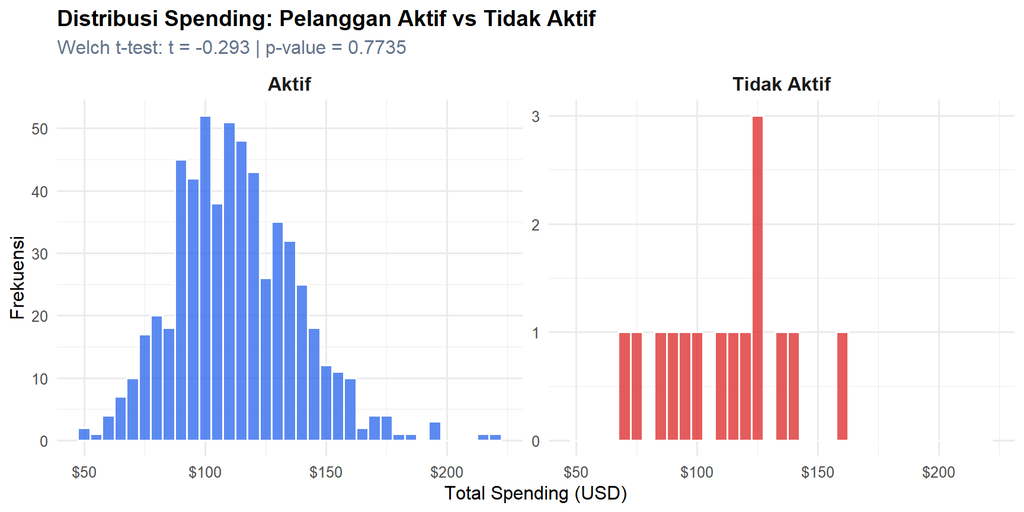

```r
data_uji |>
  mutate(Status = ifelse(active == 1, "Aktif", "Tidak Aktif")) |>
  ggplot(aes(x = total_spending, fill = Status)) +
  geom_histogram(binwidth = 5, alpha = 0.75, position = "identity", color = "white") +
  facet_wrap(~ Status, ncol = 2, scales = "free_y") +
  scale_fill_manual(values = c("Aktif" = "#2563eb", "Tidak Aktif" = "#dc2626")) +
  scale_x_continuous(labels = dollar_format(prefix = "$")) +
  labs(
    title    = "Distribusi Spending: Pelanggan Aktif vs Tidak Aktif",
    subtitle = paste0("Welch t-test: t = ", round(hasil_uji$statistic, 3),
                      " | p-value = ", round(hasil_uji$p.value, 4)),
    x = "Total Spending (USD)",
    y = "Frekuensi"
  ) +
  theme_minimal(base_size = 12) +
  theme(
    legend.position = "none",
    strip.text      = element_text(face = "bold", size = 12),
    plot.title      = element_text(face = "bold", size = 14),
    plot.subtitle   = element_text(color = "#64748b")
  )
```

Visualisasi ini digunakan untuk membandingkan distribusi total spending antara pelanggan aktif dan tidak aktif serta menampilkan hasil uji t secara langsung pada judul grafik.

## 5.6 Interpretasi

Berdasarkan hasil Welch t-test, diperoleh nilai t = -0,293 dengan p-value = 0,7735. Karena p-value = 0,7735 > α = 0,05, maka H₀ gagal ditolak. Artinya, tidak terdapat perbedaan yang signifikan secara statistik antara rata-rata total spending pelanggan aktif dan pelanggan tidak aktif pada tingkat kepercayaan 95%.

Pelanggan aktif memiliki rata-rata spending sebesar $112,58 dengan standar deviasi $25,39, sedangkan pelanggan tidak aktif memiliki rata-rata $110,66 dengan standar deviasi $24,98. Selisih keduanya hanya sekitar $1,92, yang secara statistik tidak cukup untuk menyimpulkan adanya perbedaan antar kelompok.